# Applied Cloud Computing - Computer Lab 2

**By: Tim Josefsson**, tijo9673@student.uu.se

## Task 1 - Part I & Part 2

This notebook consists of instructions, exercises and questions that form the practical part of Lab II, Part I. In this assignment, you will learn the basics of the OpenStack Python APIs that can be used to interact directly with the IaaS services Nova (compute) and Swift (Object Store). Please prepare your solution and answers to questions directly in this notebook, and export it to PDF. Upload that PDF as to the student portal to complete Part I of the Lab.

```python
import os
import swiftclient.client
```

To establish a client connection, we will need to pass a dictionary with information about the tenant, user, credentials and the API Identity endpoint. Here, I have sourced the "openrc.sh file" obtained from the Horizon dashboard in the underlying shell prior to starting the notebook. Hence, in order to actually run the code below, you would need to do the same with your own credentials.

```python
config = {'user':os.environ['OS_USERNAME'],
          'key':os.environ['OS_PASSWORD'],
          'tenant_name':os.environ['OS_TENANT_NAME'],
          'authurl':os.environ['OS_AUTH_URL']}
```

First, we obtain a client connection to Swift (we are usign the v2 APIs)

```python
conn = swiftclient.client.Connection(auth_version=2, **config)
```

```python
# Create a container, use a UUID to make sure it has a globally unique name.
import uuid
bucket_name = "lab2_{0}".format(str(uuid.uuid4()))
print bucket_name
conn.put_container(bucket_name)
```

```
lab2_ecc0aa09-a48b-45b3-b38d-96da049d5a9e
```

## Question 1:

What does it mean that the object store has a global, flat namespace? What is the practical consequence for you when using it?

```python
# List containers
(response, bucket_list) = conn.get_account()
for bucket in bucket_list:
    print bucket['name']
```

[output not shown]

### Answer to question 1:

A global, flat namespace in object storage means that every container in the object storage is stored so that the user can immediately reach each container with having to traverse folders and directories. The practical consequence of this however is that each container can only contain objects and not other containers. In other words you cannot have subcontainers in your containers in order to store related data in the same container but separated from the main data.

```python
# Put an object in the container
object_id = conn.put_object(bucket_name, "test_object", "Hi Swift")
```

### Excercise 1:

Try to measure the speed with which you can put and get objects to and from Swift usign the API. Conduct your experiment several times to gather statistic and plot a) A estimated distribution of the time taken (in wall clock) to put and read an object of size 10MB in your swift container and b) vary the size of the object from 10kB to 100MB and plot the put and get throughput (in MB/s) times as a function of object size (for the smaller data sizes, you might need to repeat the experiment many times and obtain a statistical average). Include the resulting graphs and a description of your experiment in the report.

#### put_object experiment

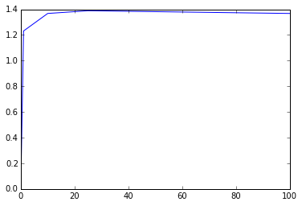

```python
# Implement you solution here. Hint, the following command
import timeit
%pylab inline
# will  make matplotlib/pylab available and plots will be displayed directly in the notebook, for example
output1M = "x"*1048576 #1MB object

output10K = ("x"*1024)*10
time10K = 0
for x in range(0,14):
    start_time = timeit.default_timer()
    object_id = conn.put_object(bucket_name, "10K_object", output10K)
    elapsed = timeit.default_timer() - start_time
    time10K += elapsed
time10K = time10K/15 #average
tp_put_10K = 0.01/time10K
print(time10K)

time1M = 0
for x in range(0,14):
    start_time = timeit.default_timer()
    object_id = conn.put_object(bucket_name, "1M_object", output1M)
    elapsed = timeit.default_timer() - start_time
    time1M += elapsed
time1M = time1M/15 #average
tp_put_1M = 1/time1M
print(time1M)

output10M = output1M*10
time10M = 0
for x in range(0,14):
    start_time = timeit.default_timer()
    object_id = conn.put_object(bucket_name, "10M_object", output10M)
    elapsed = timeit.default_timer() - start_time
    time10M += elapsed
time10M = time10M/15 #average
tp_put_10M = 10/time10M
print(time10M)

output25M = output1M*25
time25M = 0
for x in range(0,14):
    start_time = timeit.default_timer()
    object_id = conn.put_object(bucket_name, "25M_object", output25M)
    elapsed = timeit.default_timer() - start_time
    time25M += elapsed
time25M = time25M/15 #average
tp_put_25M = 25/time25M
print(time25M)

output100M = output1M*100
time100M = 0
for x in range(0,14):
    start_time = timeit.default_timer()
    object_id = conn.put_object(bucket_name, "100M_object", output100M)
    elapsed = timeit.default_timer() - start_time
    time100M += elapsed
time100M = time100M/15 #average
tp_put_100M = 100/time100M
print(time100M)

plt.plot([0.01,1,10,25,100],[tp_put_10K,tp_put_1M,tp_put_10M,tp_put_25M,tp_put_10M])
```

[output not shown]